# STAT 240 Project Draft

- Group: 6
- Names:
  - Yasmine Reis
  - Anthony Wu
  - Amal Khan
  - Sofia Rodriguez

## Background

Since 1996, the FBI has been required to collect hate crime data through the Uniform Crime Reporting (UCR) Program annually. This data comes from city, county, college and university, state, tribal, and federal agencies. Hate crime statistics are made publicly available every year. According to the FBI, a hate crime is a crime “which is motivated, in whole or in part, by the offender’s bias(es) against a: race, religion, disability, sexual orientation, ethnicity, gender, gender identity” [^3]. This is even if the offender incorrectly perceives the victim as a member of a certain group. This data is collected by either voluntary reporting from agencies or through investigation by law enforcement officers. These incidents are then reported to the FBI UCR program from where this data was collected [^4].  
Analyzing the types and likelihood of hate crimes help determine which states are at higher risk for certain dangers. This helps marginalized populations living in these states remain aware and vigilant. Additionally, it helps inform policy makers of local and state governments about what changes need to be made to help support marginalized populations [^5]. It can help inform governments as to how efficiently allocate budgets as well. Keeping track of changes in the trends of the amount and type of hate crimes can then help prove or disprove whether certain policy changes were effective or not. This is relevant because hate crime offenders are not always prosecuted so it’s integral to community safety to monitor changes in these statistics.  
Some argue that hate crimes in more recent years have increased due to a backlash against BLM protests and Anti-Asian hate due to the pandemic, so it will be interesting to look at 2013 specifically and see what the trends were before these larger political/social events occurred. This can also allow us to see if there truly has been a change in the types/prevalence of hate crimes since then.  
Specifically in Wisconsin, hate crime reporting is not required by law enforcement (½ of states in U.S) and hate crime training for law enforcement officers is not provided (⅔ of states in U.S) [^6] Wisconsin law also offers alternative sentencing for hate crime offenders like mediation. Hate crime laws vary state by state so we thought that looking specifically at Wisconsin’s data trends would be interesting and relevant as students of UW-Madison.

#### A Look At Our Main Variables

| Name | Description |
| --- | --- |
| State | State that the hate crime took place |
| Agency Type | Type of area where data was collected (city, county, colleges) |
| Agency Name | Title of agency type |
| Hate Crime | Type of hate crime that occured |
| Quarter | Quarter of the year that the crime took place |
| Population | Number of people living in the area where the data was collected |

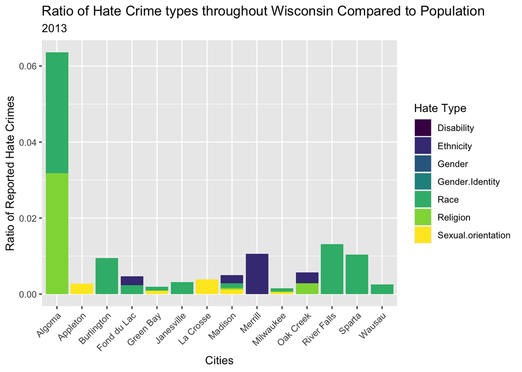

To examine the prevalence of race related hate crimes, we perform a two-tail hypothesis test.

## Analysis

### Data Cleaning

#### First, we look at the data.

```r
kable(head(data))
```

| State | Agency.type | Agency.name | Race | Religion | Sexual.orientation | Ethnicity | Disability | Gender | Gender.Identity | X1st.quarter | X2nd.quarter | X3rd.quarter | X4th.quarter | Population |
| --- | --- | --- | --- | --- | --- | --- | --- | --- | --- | --- | --- | --- | --- | --- |
| Alabama | Cities | Florence | 2 | 0 | 0 | 0 | 0 | 0 | 0 | 0 | 1 | 0 | 1 | 39,481 |
| Alabama | Cities | Hoover | 0 | 0 | 1 | 0 | 0 | 0 | 0 | 0 | 1 | 0 | 0 | 84,139 |
| Alabama | Cities | Prattville | 2 | 0 | 0 | 0 | 0 | 0 | 0 | 1 | 0 | 1 | 0 | 35,154 |
| Alabama | Cities | Tuscaloosa | 1 | 0 | 0 | 0 | 0 | 0 | 0 | 0 | 0 | 1 | 0 | 94,126 |
| Alaska | Cities | Anchorage | 8 | 0 | 0 | 0 | 0 | 0 | 0 | 2 | 3 | 3 | 0 | 299,455 |
| Arizona | Cities | Apache Junction | 1 | 0 | 0 | 0 | 0 | 0 | 0 | 1 | 0 | 0 | NA | 36,626 |

#### Since we only want the cities, we filter the agency type to be cities only.

- We add a total number of cases column
- Fill the NA value with 0
- Clean up the labels

| State | Agency Type | Agency Name | Race | Religion | Sexual Orientation | Ethnicity | Disability | Gender | Gender Identity | 1st Quarter | 2nd Quarter | 3rd Quarter | 4th Quarter | Population | total |
| --- | --- | --- | --- | --- | --- | --- | --- | --- | --- | --- | --- | --- | --- | --- | --- |
| Alabama | Cities | Florence | 2 | 0 | 0 | 0 | 0 | 0 | 0 | 0 | 1 | 0 | 1 | 39,481 | 2 |
| Alabama | Cities | Hoover | 0 | 0 | 1 | 0 | 0 | 0 | 0 | 0 | 1 | 0 | 0 | 84,139 | 1 |
| Alabama | Cities | Prattville | 2 | 0 | 0 | 0 | 0 | 0 | 0 | 1 | 0 | 1 | 0 | 35,154 | 2 |
| Alabama | Cities | Tuscaloosa | 1 | 0 | 0 | 0 | 0 | 0 | 0 | 0 | 0 | 1 | 0 | 94,126 | 1 |
| Alaska | Cities | Anchorage | 8 | 0 | 0 | 0 | 0 | 0 | 0 | 2 | 3 | 3 | 0 | 299,455 | 8 |
| Arizona | Cities | Apache Junction | 1 | 0 | 0 | 0 | 0 | 0 | 0 | 1 | 0 | 0 | 0 | 36,626 | 1 |

## Which type of hate crimes are reported the most?

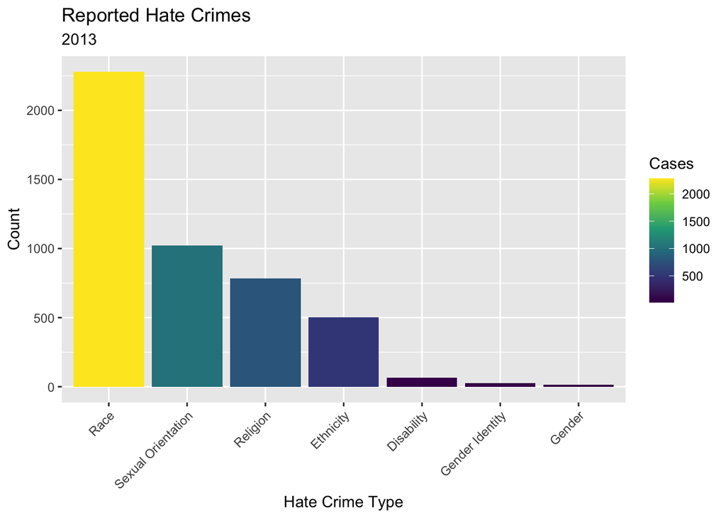

## What is the top 10 state with the highest number of Crimes?

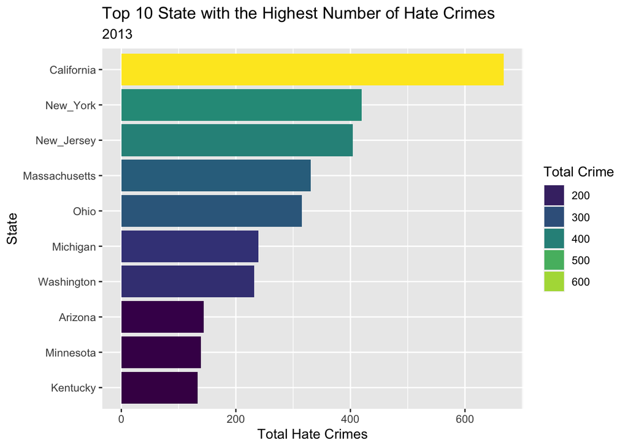

## What is the top 10 state with the highest number of Race Crimes?

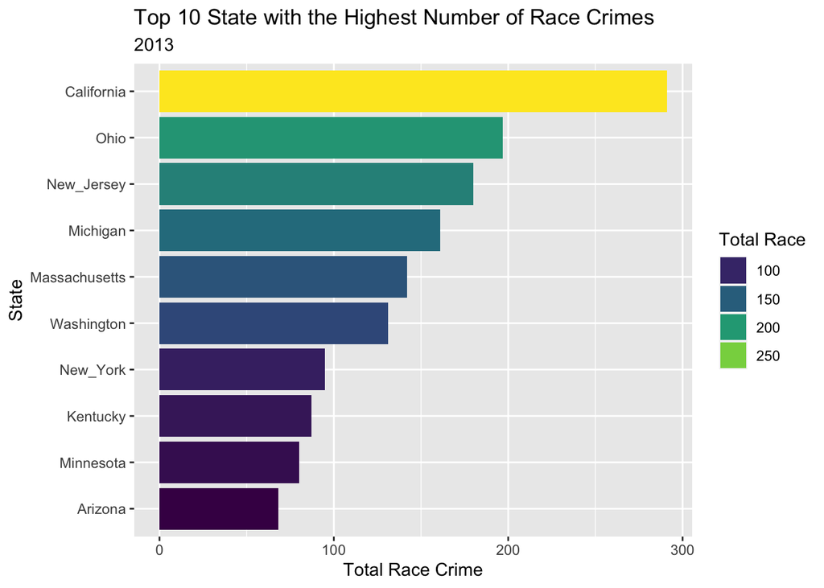

## Which quarter reported the highest number of hate crimes statewide?

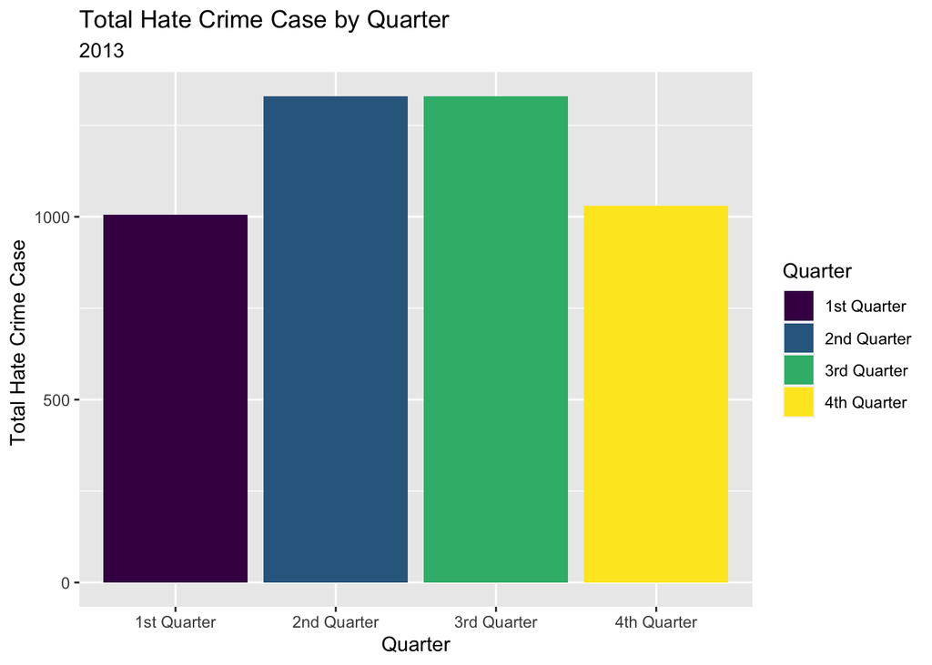

## Let’s see about Wisconsin hate crime situation

| State | Total_Crime | Total_Race_Crime | Total_population | Race_Crime_p |
| --- | --- | --- | --- | --- |
| Wisconsin | 41 | 18 | 1302106 | 0.4390244 |

- The total crime cases in Wisconsin is 41 and the race crime is 18, the observed proportion is 0.439

## Which quarter reported the highest number of hate crimes in Wisconsin?

| 1st Quarter | 2nd Quarter | 3rd Quarter | 4th Quarter |
| --- | --- | --- | --- |
| 10 | 15 | 11 | 5 |

## Is the proportion of race crimes in Wisconsin 0.5? (Hypothesis Testing)

- Null Hypothesis: $p_0 = 0.5$
- Alternative Hypothesis: $p_0 \neq 0.5$
- Test Statistic: $X$, number of race hate crime
- By null hypothesis, $X\sim Bin(41,0.5)$
- Do a two tail hypothesis test and calculate the $p$ value, which is $P(X\leq18) + P(X\geq23)$
- The resulting p value is .5327. As the P-value is higher than 0.05, we cannot prove with a high degree of statistical certainty that the proportion of race hate crimes in Wisconsin is not .5.
- The evidence is consistent with Hate Crimes related to race being 50% of Hate Crimes committed in Wisconsin according to the FBI in 2013 (p = 0.53, two tail Binomial test)

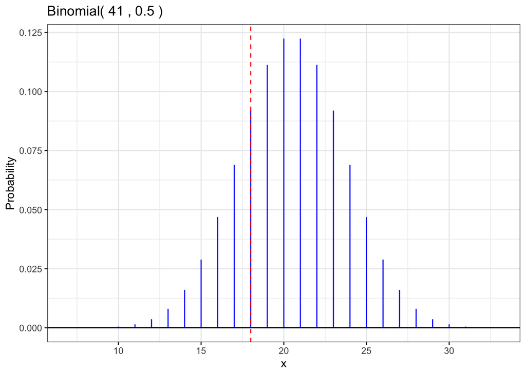

#### Close look at left tail.

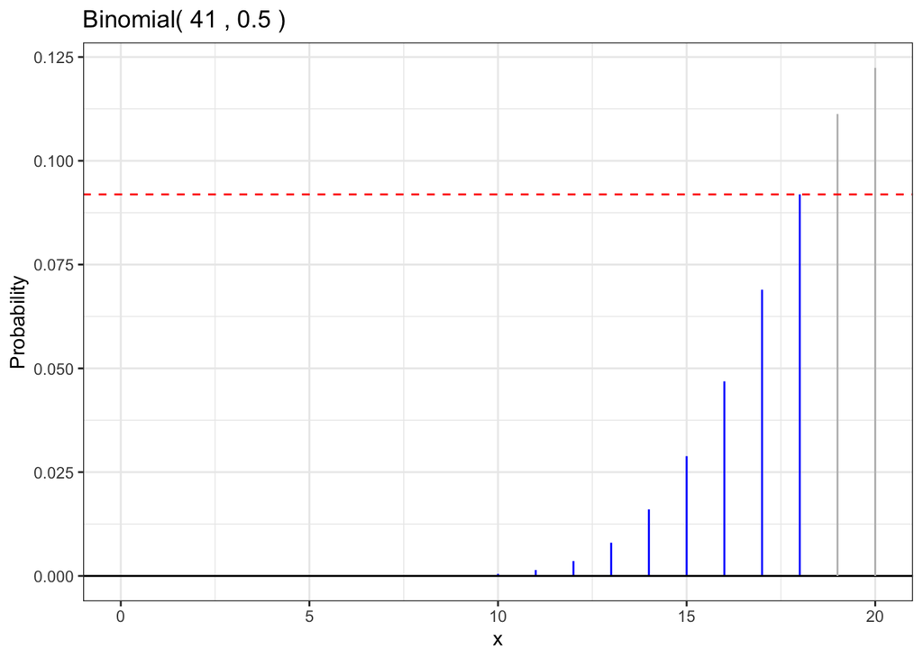

#### Close look at right tail.

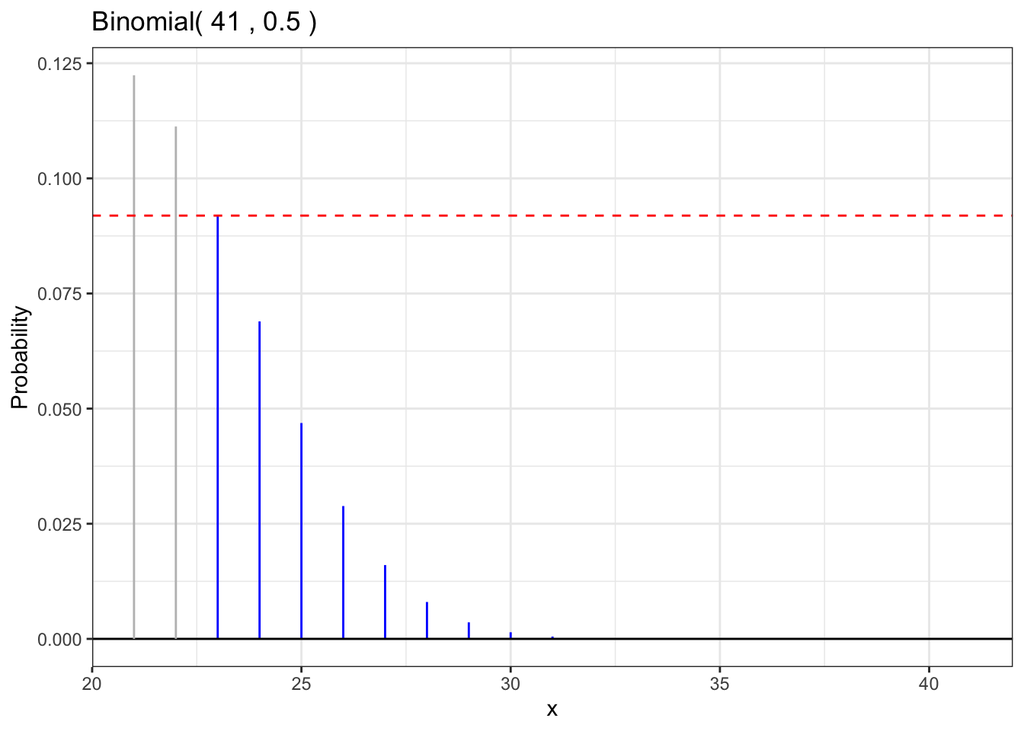

## What is a 95% confidence interval for the proportion of race crime in Wisconsin?

- The Wald estimator $\hat{p} = \frac{X}{n}$ = 0.439
- The standard error $\text{SE}(\hat{p}) = \sqrt{ \frac{p(1-p)}{n} }$

| x |
| --- |
| 0.287116456378849 |
| and |
| 0.590932324108956 |

## Discussion

One limitation of our project is our small sample size due to only looking at one year and one state specifically. Additionally, hate crimes reported may not fully capture the actual prevalence of hate crimes, as different states have different rules for what classifies as a hate crime, and victims may not report these crimes for various reasons.

## References

A = https://www.channel3000.com/report-where-wisconsin-stands-on-hate-crime-laws-in-comparison-to-other-states/ B = https://pubsonline.informs.org/do/10.1287/orms.2021.03.17/full/ C = https://www.fbi.gov/file-repository/ucr/ucr-hate-crime-data-collection-guidelines-training-manual-030122.pdf/view E (https://www.fbi.gov/about-us/cjis/ucr/hate-crime/2013) D = https://www.channel3000.com/fbi-reports-44-increase-in-wisconsin-hate-crimes-last-year-heres-why-thats-only-a-small-part-of-the-story/

[^1]: D
[^2]: E
[^3]: E
[^4]: C
[^5]: B
[^6]: A